# 02: Resampling Methods

# Which Permutation Method Should We Use?

GLS Factorial Model (Adams & Collyer, unpubl.)

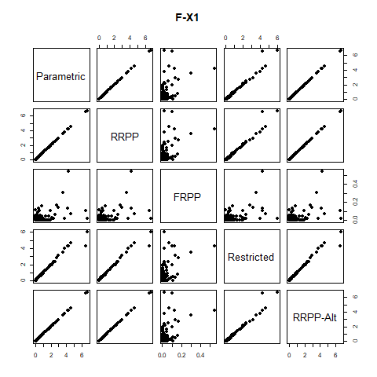

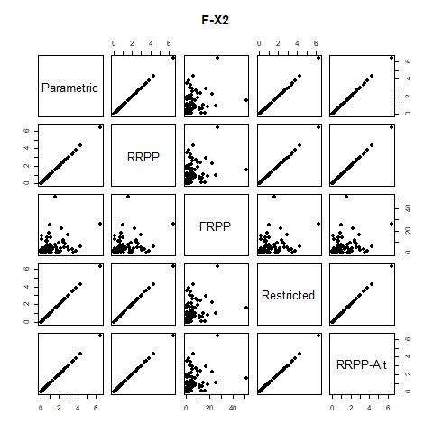

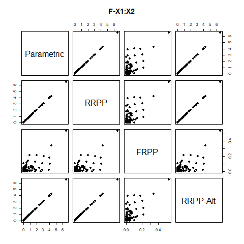

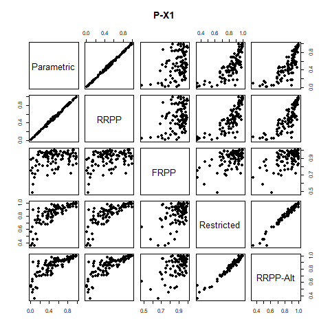

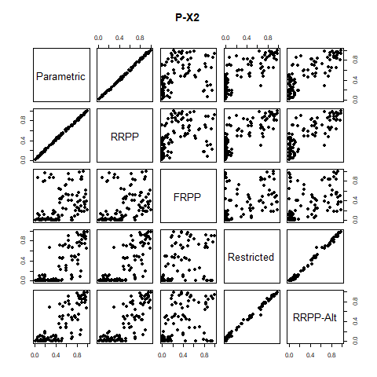

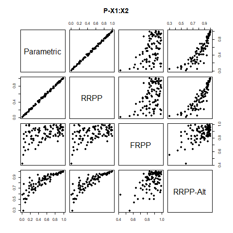

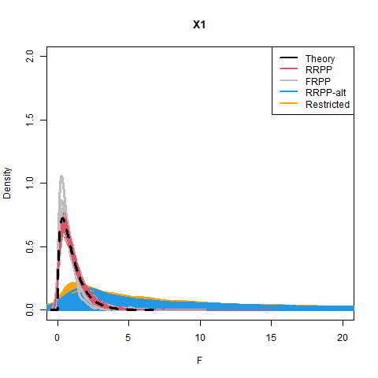

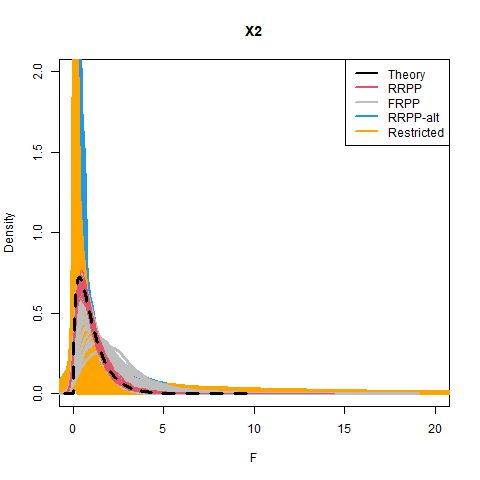

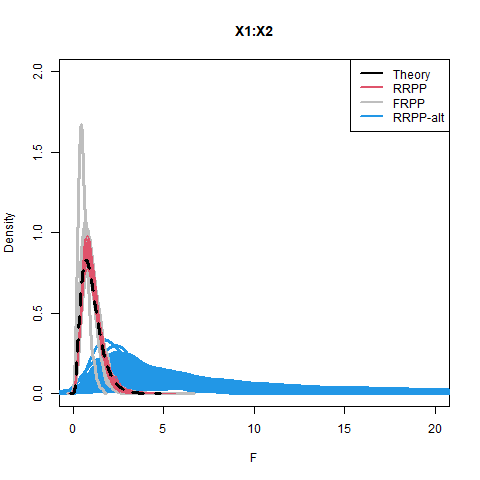

**Only RRPP is appropriate**

# RRPP & Multivariate Data

RRPP is unaltered for multivariate data

Shuffle *ROWS* of $\mathbf{E}_{R}$

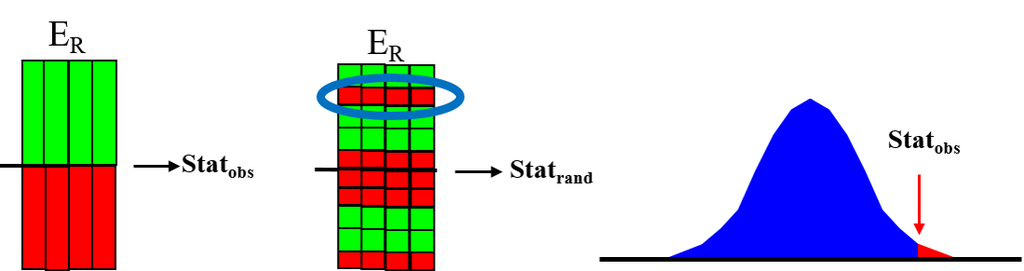

The rest of the procedure is **unchanged**

# RRPP & Distance Data

Mantel tests (see Matrix Covariation) shuffle rows *AND* columns of distance matrices

Prefered approach: RRPP

1: PCoA of distance matrix to obtain coordinates for $\small{Y}$

2: Fit model: $\small \mathbf{Y}=\mathbf{X}\mathbf{\beta } +E$

3: RRPP of rows of $\mathbf{E}_{R}$

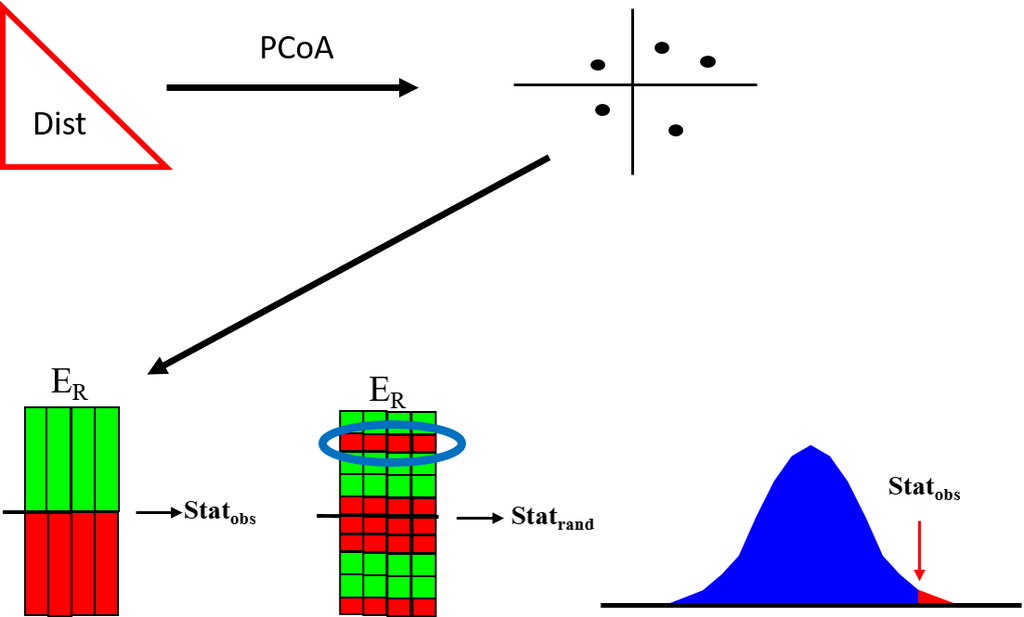

# Residual Randomization (RRPP): Example

Does pupfish body shape differ between populations (marsh vs. sinkhole) or between the sexes?

This is a factorial MANOVA: Y~ Pop + Sex + Pop:Sex

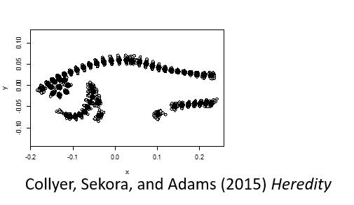

```
##           Df       SS        MS     Rsq      F      Z Pr(>F)
## Sex        1 0.015780 0.0157802 0.28012 28.209 4.7773  0.001 **
## Pop        1 0.009129 0.0091294 0.16206 16.320 4.7097  0.001 **
## Sex:Pop    1 0.003453 0.0034532 0.06130  6.173 3.7015  0.001 **
## Residuals 50 0.027970 0.0005594 0.49651
## Total     53 0.056333
## ---
## Signif. codes:  0 '***' 0.001 '**' 0.01 '*' 0.05 '.' 0.1 ' ' 1
```

# Residual Randomization (RRPP): Example

PCA of data and predicted values (see GLM lecture)

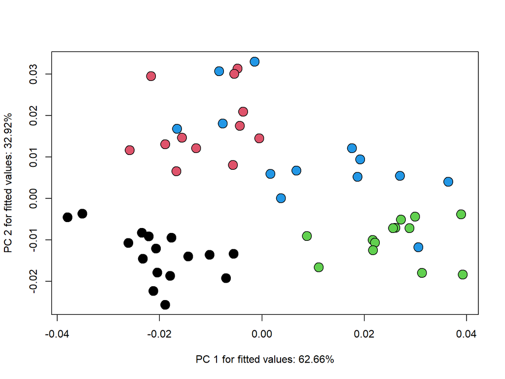

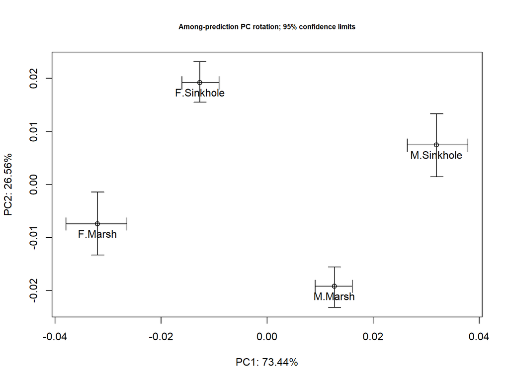

# More Complex Designs

- RRPP appropriate for ‘standard’ OLS (ordinary least squares) models
  - ANOVA designs
  - Regression designs
  - Factorial models
  - ANCOVA models

More generally RRPP is also appropriate for GLS (generalized least squares) models

These are models where covariance between objects is not zero (e.g., phylogenetic non-independence, spatial non-independence, temporal non-independence, etc.).

OLS is a special case of GLS (see LM lecture)

# CONCLUSIONS

Resampling methods are of primary importance in multivariate analysis

Methods are flexible, and may be used with univariate or high-dimensional data

**RRPP** is *the* most general approach (and the only approach that is appropriate for GLS models)